# miRNA_analysis

Laura

2024-07-09

## Installation

```r
if (!require("BiocManager", quietly = TRUE))
  install.packages("BiocManager")

BiocManager::install("DESeq2")
install.packages("readxl")
install.packages("tidyverse")
install.packages("ggplot2")
install.packages("reshape2")
install.packages ("pheatmap")
```

```r
library(DESeq2, quietly = TRUE)
library(readxl)
library(tidyverse,quietly = TRUE)
```

## Preprocessing

```r
print(getwd())
```

```
## [1] "C:/Users/lgonzalezp/Desktop/miRNA_analysis/src"
```

```r
counts_xlsx <- "C:/Users/lgonzalezp/Desktop/miRNA_analysis/data/12.1.miRNAExp/Readcount_TPM.xls"
counts_csv_path <- "C:/Users/lgonzalezp/Desktop/miRNA_analysis/data/readcounts.csv"
```

### Create readcount file from Novogene

Crea un data frame a partir de un excell de Novogene que contiene los contajes para cada miRNA.

```r
pre_counts <- read.delim(counts_xlsx)
```

### Variable transformation

Seleciona los datos de contaje crudos, sin normalizar, se renombran eliminando la termianción “.readcount” y se guardan como .csv en el directorio “data”.

```r
pre_counts2 <- pre_counts %>%
  select(ends_with(".readcount")) %>%
  rename_with(~gsub(".readcount","",.x,fixed = TRUE))

write.csv(pre_counts2,counts_csv_path,row.names = FALSE)
```

### Create metadata file

Crea dataframe que contiene el nombre de las muestras y el grupo al que pertenecen, “disease” o “control”, que serán las variables cualitativas del posterior análisis.

```r
meta_csv_path <- "C:/Users/lgonzalezp/Desktop/miRNA_analysis/data/meta.csv"
samples <- colnames(pre_counts)[2:13]
condition <- sapply(samples,function(x) ifelse(grepl('ATTR',x,fixed = TRUE),'disease','control'))

metadata <- data.frame(condition)
metadata <- rownames_to_column(metadata,"ID")
print(metadata)
```

```
##                 ID condition
## 1  ATTR1.readcount   disease
## 2  ATTR2.readcount   disease
## 3  ATTR3.readcount   disease
## 4  ATTR4.readcount   disease
## 5  ATTR5.readcount   disease
## 6  ATTR6.readcount   disease
## 7   DCM1.readcount   control
## 8   DCM2.readcount   control
## 9   DCM3.readcount   control
## 10  DCM4.readcount   control
## 11  DCM5.readcount   control
## 12  DCM6.readcount   control
```

```r
write.csv(metadata, meta_csv_path,row.names = FALSE)
```

## Analysis

### DEseq

Establece “condition” (que puede ser “disease” o “control”) como el factor para el análisis y comparación de las muestras.

```r
readcounts <- read_csv(counts_csv_path,) %>% column_to_rownames("sRNA")
head(readcounts)
```

```
##                  ATTR1  ATTR2 ATTR3 ATTR4 ATTR5 ATTR6  DCM1  DCM2  DCM3  DCM4
## hsa-let-7a-2-3p      0      0     0     1     0     0     0     0     0     4
## hsa-let-7a-3p       44     27    19    46    18    42    33    16    39    58
## hsa-let-7a-5p   179474 101411 49666 76787 21167 74985 70611 84062 59871 73681
## hsa-let-7b-3p       48     33    16    45    21    41    30    46    19    37
## hsa-let-7b-5p    29001  18402  9610 14365  4345 14703 14012 17151 12920 17768
## hsa-let-7c-3p       31     29     1    21     8    38    26    26    12    21
##                  DCM5  DCM6
## hsa-let-7a-2-3p     0     2
## hsa-let-7a-3p      39    41
## hsa-let-7a-5p   51250 69058
## hsa-let-7b-3p      18    33
## hsa-let-7b-5p   10806 15971
## hsa-let-7c-3p      10     6
```

```r
metadata <- read_csv(meta_csv_path) %>% mutate(condition = factor(condition))
head(metadata)
```

```
## # A tibble: 6 × 2
##   ID              condition
##   <chr>           <fct>
## 1 ATTR1.readcount disease
## 2 ATTR2.readcount disease
## 3 ATTR3.readcount disease
## 4 ATTR4.readcount disease
## 5 ATTR5.readcount disease
## 6 ATTR6.readcount disease
```

```r
deseq <- DESeqDataSetFromMatrix(countData = readcounts,
                              colData = metadata,
                              design = ~ condition)
deseq <- DESeq(deseq)
results <- results(deseq)
resultsNames(deseq)
```

```
## [1] "Intercept"                    "condition_disease_vs_control"
```

```r
results_table <- data.frame(results(deseq))
head(results_table)
```

```
##                     baseMean log2FoldChange     lfcSE       stat    pvalue
## hsa-let-7a-2-3p 4.623187e-01     -1.6651558 2.3034696 -0.7228903 0.4697473
## hsa-let-7a-3p   3.365508e+01     -0.2457082 0.3005867 -0.8174286 0.4136835
## hsa-let-7a-5p   6.972646e+04      0.1312233 0.2498088  0.5252947 0.5993783
## hsa-let-7b-3p   3.070048e+01      0.1302797 0.2881992  0.4520472 0.6512350
## hsa-let-7b-5p   1.381914e+04     -0.1052893 0.2078642 -0.5065293 0.6124851
## hsa-let-7c-3p   1.751918e+01      0.1884893 0.5096190  0.3698632 0.7114844
##                      padj
## hsa-let-7a-2-3p 0.9892678
## hsa-let-7a-3p   0.9892678
## hsa-let-7a-5p   0.9892678
## hsa-let-7b-3p   0.9892678
## hsa-let-7b-5p   0.9892678
## hsa-let-7c-3p   0.9892678
```

## Volcano plot

```r
library(ggplot2)
```

### Build data.frame

Añade nueva columna de con los valores -log10 de padj(necesaria para la representación del volcano plot). Elimina las filas con valor NA en el padj.

```r
results_table$Minuslog10padj <- -log10(results_table$padj)

logical_na <- !is.na(results_table$padj)
filtered_results <-results_table[logical_na,]
```

Selecciona aquellos microRNAs cuyo padj es menos a 0.05, es decir, significativos.

```r
significant <- filtered_results$padj < 0.05 # Seleccionar valores significativos
significant_results <- filtered_results[significant,]
head(significant_results)
```

```
##                    baseMean log2FoldChange     lfcSE      stat       pvalue
## hsa-miR-124-3p    19.824485       4.882285 0.5976005  8.169814 3.088652e-16
## hsa-miR-1269b      3.285425       4.119215 1.1304648  3.643825 2.686165e-04
## hsa-miR-129-5p    93.930392       1.473564 0.4264673  3.455279 5.497236e-04
## hsa-miR-1298-5p    6.872956       3.901911 0.8657610  4.506914 6.577729e-06
## hsa-miR-140-3p  6211.707392      -0.703235 0.1814860 -3.874873 1.066805e-04
## hsa-miR-182-5p  2082.866776       2.122126 0.3494058  6.073528 1.251298e-09
##                         padj Minuslog10padj
## hsa-miR-124-3p  1.360037e-13      12.866449
## hsa-miR-1269b   2.087308e-02       1.680413
## hsa-miR-129-5p  3.822025e-02       1.417706
## hsa-miR-1298-5p 7.436547e-04       3.128629
## hsa-miR-140-3p  1.006607e-02       1.997140
## hsa-miR-182-5p  2.639679e-07       6.578449
```

### Representation

Para la representación, se separan los datos en tres poblaciones: con valores de padj no significativos (negro), con padj signitivativo y valor absoluto del log2Foldchange postivo (verde) y valores con padj signitivativo y valor absoluto del log2Foldchange negativo (rojo). Algráfico se añade una linea azul que indica el valor límite de significancia.

```r
positive <- significant_results$log2FoldChange >0
significant_positive <- significant_results[positive,]
head(significant_positive)
```

```
##                    baseMean log2FoldChange     lfcSE     stat       pvalue
## hsa-miR-124-3p    19.824485       4.882285 0.5976005 8.169814 3.088652e-16
## hsa-miR-1269b      3.285425       4.119215 1.1304648 3.643825 2.686165e-04
## hsa-miR-129-5p    93.930392       1.473564 0.4264673 3.455279 5.497236e-04
## hsa-miR-1298-5p    6.872956       3.901911 0.8657610 4.506914 6.577729e-06
## hsa-miR-182-5p  2082.866776       2.122126 0.3494058 6.073528 1.251298e-09
## hsa-miR-183-5p  1363.539160       2.861075 0.3169431 9.027094 1.762902e-19
##                         padj Minuslog10padj
## hsa-miR-124-3p  1.360037e-13      12.866449
## hsa-miR-1269b   2.087308e-02       1.680413
## hsa-miR-129-5p  3.822025e-02       1.417706
## hsa-miR-1298-5p 7.436547e-04       3.128629
## hsa-miR-182-5p  2.639679e-07       6.578449
## hsa-miR-183-5p  1.164397e-16      15.933899
```

```r
negative <- significant_results$log2FoldChange <0
significant_negative <- significant_results[negative,]
head(significant_negative)
```

```
##                    baseMean log2FoldChange     lfcSE       stat       pvalue
## hsa-miR-140-3p  6211.707392      -0.703235 0.1814860  -3.874873 1.066805e-04
## hsa-miR-200b-3p   29.005370      -1.213988 0.3328887  -3.646829 2.654962e-04
## hsa-miR-200c-3p   20.233300      -1.986030 0.3828598  -5.187357 2.133001e-07
## hsa-miR-205-5p     7.607465      -6.381086 0.9478882  -6.731898 1.674643e-11
## hsa-miR-217-5p    20.657511      -2.614080 0.6855162  -3.813301 1.371231e-04
## hsa-miR-375-3p    43.013220      -3.839511 0.3499296 -10.972240 5.196893e-28
##                         padj Minuslog10padj
## hsa-miR-140-3p  1.006607e-02       1.997140
## hsa-miR-200b-3p 2.087308e-02       1.680413
## hsa-miR-200c-3p 3.130771e-05       4.504349
## hsa-miR-205-5p  4.424407e-09       8.354145
## hsa-miR-217-5p  1.207597e-02       1.918078
## hsa-miR-375-3p  6.865095e-25      24.163353
```

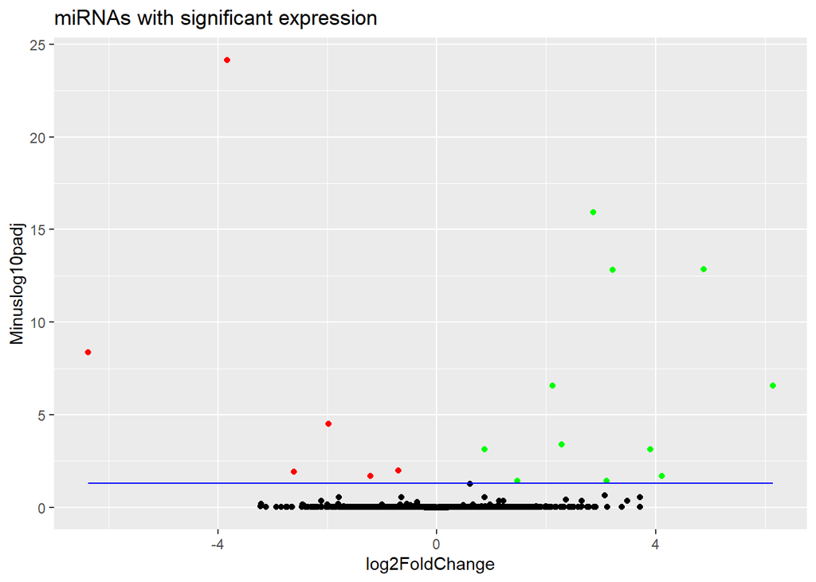

```r
trans <- -log10(0.05) # Valor límite de significancia

#significant_positive$miRNA <- row.names (significant_positive) # Discernir puntos solapados

v<-ggplot() +
  geom_point(data= filtered_results, aes(x=log2FoldChange, y = Minuslog10padj)) +
  geom_point(data = significant_positive,aes( x=log2FoldChange, y = Minuslog10padj), color="green")+
  geom_point(data = significant_negative,aes( x=log2FoldChange, y = Minuslog10padj), color="red")+
  geom_line(data=filtered_results,aes(x=log2FoldChange,y=trans),color="blue")+
  ggtitle("miRNAs with significant expression")

# jpeg("volcano_plot.jpg", width = 800, height = 600)
print(v)
```

```r
# dev.off()
```

### Order microRNAs list

Ordena los microRNAs con valor padj significativo de forma decreciente al valor absoluto del log2Foldchange y de forma creciente según padj. Se escribe un archivo .csv en el directorio “data”.

```r
lista <- arrange (significant_results,
  desc(abs(significant_results$log2FoldChange))) %>%
  arrange (significant_results, significant_results$padj)
results_path <-"C:/Users/lgonzalezp/Desktop/miRNA_analysis/data/miRNAs_results.csv"
write.csv (lista,results_path)
```

## Correlation

### From DESeq normalization

Normalización de datos de contaje crudos.

```r
head(readcounts)
```

```
##                  ATTR1  ATTR2 ATTR3 ATTR4 ATTR5 ATTR6  DCM1  DCM2  DCM3  DCM4
## hsa-let-7a-2-3p      0      0     0     1     0     0     0     0     0     4
## hsa-let-7a-3p       44     27    19    46    18    42    33    16    39    58
## hsa-let-7a-5p   179474 101411 49666 76787 21167 74985 70611 84062 59871 73681
## hsa-let-7b-3p       48     33    16    45    21    41    30    46    19    37
## hsa-let-7b-5p    29001  18402  9610 14365  4345 14703 14012 17151 12920 17768
## hsa-let-7c-3p       31     29     1    21     8    38    26    26    12    21
##                  DCM5  DCM6
## hsa-let-7a-2-3p     0     2
## hsa-let-7a-3p      39    41
## hsa-let-7a-5p   51250 69058
## hsa-let-7b-3p      18    33
## hsa-let-7b-5p   10806 15971
## hsa-let-7c-3p      10     6
```

```r
normalized_counts <- data.frame(counts(deseq,normalized=TRUE))
head(normalized_counts)
```

```
##                        ATTR1       ATTR2        ATTR3        ATTR4       ATTR5
## hsa-let-7a-2-3p      0.00000     0.00000     0.000000 8.633864e-01     0.00000
## hsa-let-7a-3p       30.15943    22.95124    23.187528 3.971578e+01    35.53768
## hsa-let-7a-5p   123018.93975 86204.00073 60612.197683 6.629685e+04 41790.33738
## hsa-let-7b-3p       32.90120    28.05151    19.526339 3.885239e+01    41.46063
## hsa-let-7b-5p    19878.49088 15642.54392 11728.007485 1.240255e+04  8578.40109
## hsa-let-7c-3p       21.24869    24.65133     1.220396 1.813112e+01    15.79452
##                       ATTR6        DCM1        DCM2        DCM3        DCM4
## hsa-let-7a-2-3p     0.00000     0.00000     0.00000     0.00000     2.97865
## hsa-let-7a-3p      33.29632    34.63628    15.62112    46.80405    43.19042
## hsa-let-7a-5p   59445.81534 74112.18410 82071.39077 71851.42462 54867.46915
## hsa-let-7b-3p      32.50355    31.48752    44.91071    22.80198    27.55251
## hsa-let-7b-5p   11656.08886 14706.77265 16744.86002 15505.34326 13231.16125
## hsa-let-7c-3p      30.12524    27.28919    25.38431    14.40125    15.63791
##                        DCM5         DCM6
## hsa-let-7a-2-3p     0.00000     1.705788
## hsa-let-7a-3p      43.79244    34.968662
## hsa-let-7a-5p   57547.75741 58899.167737
## hsa-let-7b-3p      20.21190    28.145509
## hsa-let-7b-5p   12133.87447 13621.573285
## hsa-let-7c-3p      11.22883     5.117365
```

```r
library(reshape2) #Necesario para generar long data frames.
```

#### Representation

Genera un dataframe con los valores de correlación entre las diferentes muestras (cor). Luego se genera una long data frame (melt).

```r
trans_norm <- log10(normalized_counts+1)
cor_data <- cor(trans_norm, method="pearson")
cor_data <- melt(cor_data)
head(cor_data)
```

```
##    Var1  Var2     value
## 1 ATTR1 ATTR1 1.0000000
## 2 ATTR2 ATTR1 0.9701315
## 3 ATTR3 ATTR1 0.9659951
## 4 ATTR4 ATTR1 0.9628552
## 5 ATTR5 ATTR1 0.9482767
## 6 ATTR6 ATTR1 0.9640229
```

El gráfico representa los valores de correlación entre las muestras,indicando los valores más elevados en un azul más oscuro.

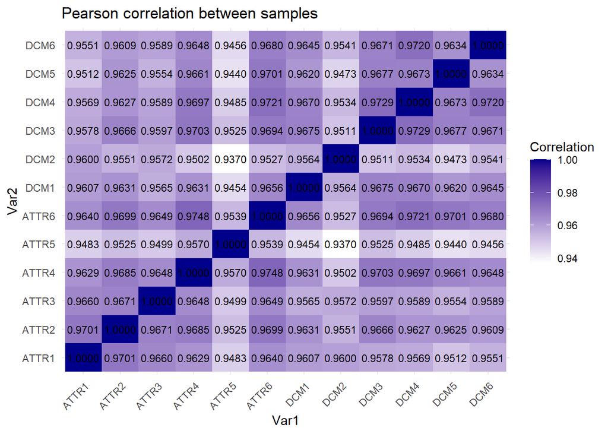

```r
pearson1<-ggplot(cor_data, aes(x=Var1, y=Var2, fill=value)) +
  geom_tile() +
  theme_minimal() +
  geom_text(aes(label = sprintf("%.4f", value)), color = "black", size = 3)+
  scale_fill_gradient(low = "white", high = "darkblue") +
  labs( fill = "Correlation") +
  theme(axis.text.x = element_text(angle = 45, hjust = 1))+
  ggtitle("Pearson correlation between samples")

#jpeg("pearson.jpg", width = 800, height = 600)
print(pearson1)
```

```r
# dev.off()
```

### From .tpm

Seleciona los datos de contaje normalizados, se renombran eliminando la termianción “.tpm” y se guardan como .csv en el directorio “data”.

```r
pre_counts_norm <- pre_counts %>%
  select(ends_with(".tpm")) %>%
  rename_with(~gsub(".tpm","",.x,fixed = TRUE))

names <- pre_counts2$sRNA
rownames(pre_counts_norm) <- names

counts_csv_path2<- "C:/Users/lgonzalezp/Desktop/miRNA_analysis/data/counts_norm.csv"
write.csv(pre_counts_norm,counts_csv_path2,row.names = TRUE)
head(pre_counts_norm)
```

```
##                       ATTR1        ATTR2        ATTR3        ATTR4       ATTR5
## hsa-let-7a-2-3p     0.00000     0.000000    0.0000000 9.793127e-02    0.000000
## hsa-let-7a-3p       4.08716     2.751487    2.7882030 4.504838e+00    4.280489
## hsa-let-7a-5p   16671.33903 10334.484032 7288.3625544 7.519848e+03 5033.617296
## hsa-let-7b-3p       4.45872     3.362929    2.3479604 4.406907e+00    4.993904
## hsa-let-7b-5p    2693.90276  1875.291390 1410.2437110 1.406783e+03 1033.262491
## hsa-let-7c-3p       2.87959     2.955301    0.1467475 2.056557e+00    1.902440
##                       ATTR6        DCM1        DCM2        DCM3         DCM4
## hsa-let-7a-2-3p    0.000000    0.000000    0.000000    0.000000    0.4355334
## hsa-let-7a-3p      4.723753    3.928858    1.776894    4.028286    6.3152341
## hsa-let-7a-5p   8433.586560 8406.683916 9335.577254 6184.038753 8022.6337988
## hsa-let-7b-3p      4.611283    3.571689    5.108569    1.962498    4.0286838
## hsa-let-7b-5p   1653.651039 1668.216780 1904.718963 1334.498851 1934.6392874
## hsa-let-7c-3p      4.273872    3.095464    2.887452    1.239473    2.2865503
##                        DCM5         DCM6
## hsa-let-7a-2-3p    0.000000    0.2369859
## hsa-let-7a-3p      5.297862    4.8582102
## hsa-let-7a-5p   6961.934182 8182.8848336
## hsa-let-7b-3p      2.445167    3.9102667
## hsa-let-7b-5p   1467.915332 1892.4506021
## hsa-let-7c-3p      1.358426    0.7109576
```

#### Representation

Genera un dataframe con los valores de correlación entre las diferentes muestras (cor). Luego se genera una long data frame (melt).

```r
transTPM <- log10(pre_counts_norm+1)
cor_data2 <- cor(transTPM, method="pearson")
cor_data2 <- melt(cor_data2)
head(cor_data2)
```

```
##    Var1  Var2     value
## 1 ATTR1 ATTR1 1.0000000
## 2 ATTR2 ATTR1 0.9869495
## 3 ATTR3 ATTR1 0.9865626
## 4 ATTR4 ATTR1 0.9808174
## 5 ATTR5 ATTR1 0.9731798
## 6 ATTR6 ATTR1 0.9809574
```

El gráfico representa los valores de correlación entre las muestras,indicando los valores más elevados en un azul más oscuro.

```r
pearsonTPM <- ggplot(cor_data2, aes(x=Var1, y=Var2, fill=value)) +
  geom_tile() +
  theme_minimal() +
  geom_text(aes(label = sprintf("%.4f", value)), color = "black", size = 3)+
  scale_fill_gradient(low = "white", high = "darkblue") +
  labs( fill = "Correlation") +
  theme(axis.text.x = element_text(angle = 45, hjust = 1))+
  ggtitle("Pearson correlation between samples (TPM)")
```

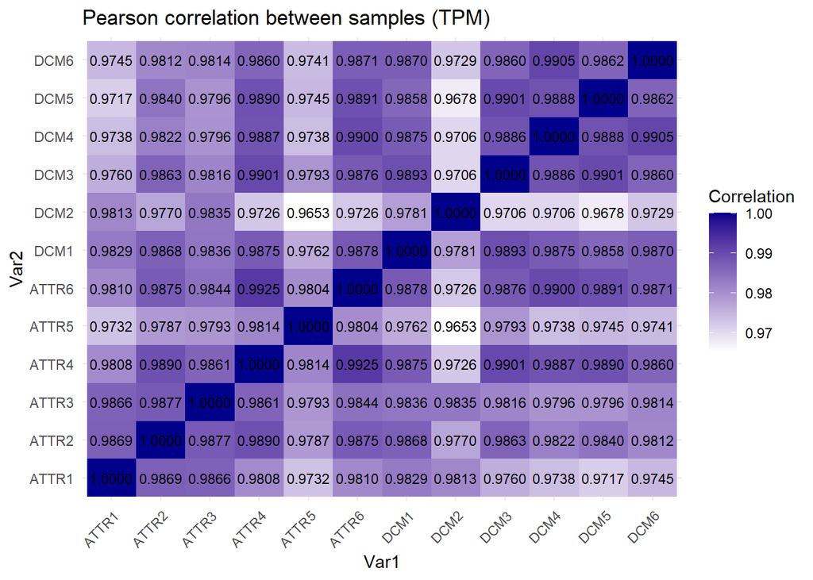

```r
# jpeg("pearsonTPM.jpg", width = 800, height = 600)
# print(pearsonTPM)
# dev.off()
pearsonTPM
```

### 1 to 1 comparison (raw)

Se usan los valores de contaje en crudo para generar un gráfico de correlación para comparación de un muestra frente a otra. Los valores se expresan en ambos ejes en log10 del valor más uno: log10(x+1). Los valores de la data frame se transforman según la anterior ecuación y se representa en cada eje una muestra. La recta de regresión se indica en rojo.

```r
transformados_raw <- log10(readcounts + 1)
head(transformados_raw)
```

```
##                    ATTR1    ATTR2    ATTR3    ATTR4     ATTR5    ATTR6     DCM1
## hsa-let-7a-2-3p 0.000000 0.000000 0.000000 0.301030 0.0000000 0.000000 0.000000
## hsa-let-7a-3p   1.653213 1.447158 1.301030 1.672098 1.2787536 1.633468 1.531479
## hsa-let-7a-5p   5.254004 5.006089 4.696068 4.885293 4.3256798 4.874980 4.848879
## hsa-let-7b-3p   1.690196 1.531479 1.230449 1.662758 1.3424227 1.623249 1.491362
## hsa-let-7b-5p   4.462428 4.264889 3.982769 4.157336 3.6380897 4.167435 4.146531
## hsa-let-7c-3p   1.505150 1.477121 0.301030 1.342423 0.9542425 1.591065 1.431364
##                     DCM2     DCM3     DCM4     DCM5      DCM6
## hsa-let-7a-2-3p 0.000000 0.000000 0.698970 0.000000 0.4771213
## hsa-let-7a-3p   1.230449 1.602060 1.770852 1.602060 1.6232493
## hsa-let-7a-5p   4.924605 4.777224 4.867361 4.709702 4.8392203
## hsa-let-7b-3p   1.672098 1.301030 1.579784 1.278754 1.5314789
## hsa-let-7b-5p   4.234315 4.111296 4.249663 4.033705 4.2033593
## hsa-let-7c-3p   1.431364 1.113943 1.342423 1.041393 0.8450980
```

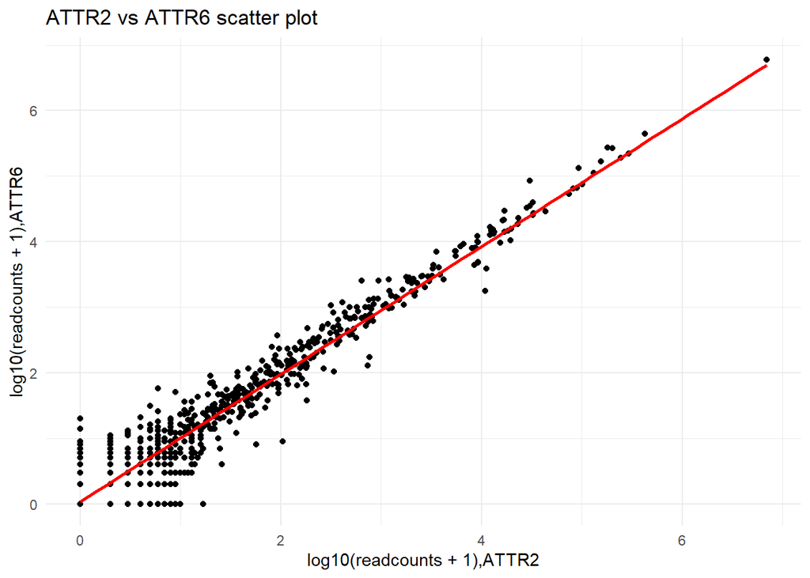

```r
s<-ggplot(transformados_raw, aes(x = ATTR2, y = ATTR6)) +
  geom_point() +
  geom_smooth(method = "lm", se = FALSE, color = "red") +
  labs(title="ATTR2 vs ATTR6",
       x = "log10(readcounts + 1),ATTR2",
       y = "log10(readcounts + 1),ATTR6") +
  theme_minimal()+
  ggtitle("ATTR2 vs ATTR6 scatter plot")
print(s)
```

```r
# jpeg("scatter.jpg", width = 800, height = 600)
# print(s)
# dev.off()
```

### 1 to 1 comparison (normalized)

En este caso se usan los valores de contaje en normalizados para generar un gráfico de correlación.

```r
transformados_norm <- log10(normalized_counts + 1)
head(transformados_norm)
```

```
##                    ATTR1    ATTR2     ATTR3     ATTR4    ATTR5    ATTR6
## hsa-let-7a-2-3p 0.000000 0.000000 0.0000000 0.2703029 0.000000 0.000000
## hsa-let-7a-3p   1.493589 1.379328 1.3835915 1.6097627 1.562741 1.535247
## hsa-let-7a-5p   5.089976 4.935532 4.7825672 4.8214995 4.621086 4.774129
## hsa-let-7b-3p   1.530215 1.463169 1.3123115 1.6004544 1.627986 1.525091
## hsa-let-7b-5p   4.298405 4.194335 4.0692613 4.0935459 3.933457 4.066590
## hsa-let-7c-3p   1.347304 1.409110 0.3464305 1.2817403 1.225168 1.493113
##                     DCM1     DCM2     DCM3      DCM4     DCM5      DCM6
## hsa-let-7a-2-3p 0.000000 0.000000 0.000000 0.5997357 0.000000 0.4322938
## hsa-let-7a-3p   1.551892 1.220660 1.679465 1.6453281 1.651205 1.5559243
## hsa-let-7a-5p   4.869895 4.914197 4.856441 4.7393228 4.760036 4.7701165
## hsa-let-7b-3p   1.511717 1.661914 1.376613 1.4556443 1.326579 1.4645716
## hsa-let-7b-5p   4.167547 4.223907 4.190509 4.1216308 4.084035 4.1342592
## hsa-let-7c-3p   1.451620 1.421346 1.187556 1.2210988 1.087385 0.7865644
```

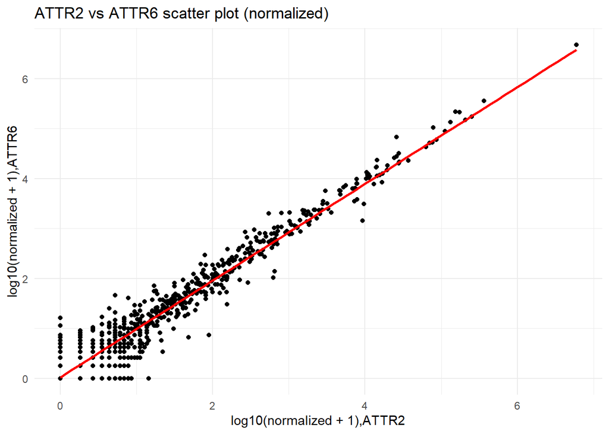

```r
s2<-ggplot(transformados_norm, aes(x = ATTR2, y = ATTR6)) +
  geom_point() +
  geom_smooth(method = "lm", se = FALSE, color = "red") +
  labs(title="ATTR2 vs ATTR6",
       x = "log10(normalized + 1),ATTR2",
       y = "log10(normalized + 1),ATTR6") +
  theme_minimal()+
  ggtitle("ATTR2 vs ATTR6 scatter plot (normalized)")
print(s2)
```

```r
# jpeg("scatter_norm.jpg", width = 800, height = 600)
# print(s2)
# dev.off()
```

```r
# Obtener los nombres de las columnas
col_names <- colnames(transformados_norm)
print(col_names)
```

```
##  [1] "ATTR1" "ATTR2" "ATTR3" "ATTR4" "ATTR5" "ATTR6" "DCM1"  "DCM2"  "DCM3"
## [10] "DCM4"  "DCM5"  "DCM6"
```

```r
# Crear un bucle para iterar sobre cada par de columnas
for (i in 1:(length(col_names))) {
  for (j in (i + 1):length(col_names)) {
    # Nombres de las columnas para el gráfico actual
    x_col <- col_names[i]
    y_col <- col_names[j]
    # Crear el plot
    p<-ggplot(transformados_norm, aes_string(x = x_col, y = y_col)) +
      geom_point() +
      ggtitle(paste("Scatter Plot de", x_col, "vs", y_col)) +
      geom_smooth(method = "lm", se = FALSE, color = "red")+
      xlab(x_col) +
      ylab(y_col)
    # Guardar el plot como JPEG
    file_name <- paste0("scatter_", x_col, "_vs_", y_col, ".jpg")
    jpeg(file_name, width = 800, height = 600)
    print(p)
    dev.off()
  }
}
```

### Mean Comparison (DESeq normalized)

Comparación de medias de ATTR y DCM. Calcula la media de expresión para cada miRNA en cada condición y estos valores los representa en un scatter plot.

```r
selected_ATTR <- trans_norm[, c(1:6)]
mean_ATTR <- rowMeans(selected_ATTR)

selected_DCM <- trans_norm[, c(7:12)]
mean_DCM <- rowMeans(selected_DCM)

mean_data <- data.frame(mean_ATTR,mean_DCM)
print(mean_data)
```

```
##                    mean_ATTR   mean_DCM
## hsa-let-7a-2-3p   0.04505049 0.17200492
## hsa-let-7a-3p     1.49404335 1.55074572
## hsa-let-7a-5p     4.83746492 4.81833489
## hsa-let-7b-3p     1.50987114 1.46617316
## hsa-let-7b-5p     4.10926577 4.15364816
## hsa-let-7c-3p     1.18381091 1.19259505
## hsa-let-7c-5p     4.06512971 4.12063167
## hsa-let-7d-3p     2.75843977 2.79628712
## hsa-let-7d-5p     3.23104999 3.18118972
## hsa-let-7e-3p     1.43190613 1.49263340
## hsa-let-7e-5p     3.78118657 3.77971763
## hsa-let-7f-1-3p   0.70405676 0.61106717
## hsa-let-7f-2-3p   0.04225407 0.27890127
## hsa-let-7f-5p     5.32851337 5.32841171
## hsa-let-7g-3p     0.11668346 0.24028839
## hsa-let-7g-5p     4.80308425 4.77697947
## hsa-let-7i-3p     0.46215011 0.42774404
## hsa-let-7i-5p     4.75909476 4.70799431
## hsa-miR-1-3p      6.74421707 6.77146128
## hsa-miR-1-5p      1.06404138 0.89252505
## hsa-miR-100-3p    0.00000000 0.05448768
## hsa-miR-100-5p    4.39968887 4.48058012
## hsa-miR-101-3p    4.24472543 4.35439341
## hsa-miR-101-5p    0.04505049 0.00000000
## hsa-miR-10392-5p  0.00000000 0.04464177
## hsa-miR-10393-3p  0.20046347 0.21617165
## hsa-miR-10394-3p  0.18479405 0.04464177
## hsa-miR-10394-5p  0.25288080 0.00000000
## hsa-miR-10395-3p  2.02889453 2.10526780
## hsa-miR-10398-5p  0.04225407 0.00000000
## hsa-miR-10399-3p  0.78052872 0.73807143
## hsa-miR-10399-5p  0.65800212 0.91984990
## hsa-miR-103a-2-5p 0.31573382 0.68929353
## hsa-miR-103a-3p   4.15496400 4.17696857
## hsa-miR-103b      4.14457826 4.16609212
## hsa-miR-10401-3p  0.28857236 0.13716383
## hsa-miR-105-3p    0.00000000 0.04464177
## hsa-miR-105-5p    0.00000000 0.14153906
## hsa-miR-10527-5p  0.51467395 0.42096514
```

[output cut: 1270 more lines]

```
## novel_411         0.85291029 1.11176258
## novel_412         0.22152151 0.31201451
## novel_431         0.11574751 0.00000000
## novel_438         0.08678449 0.04930954
## novel_441         0.18479405 0.00000000
## novel_447         0.00000000 0.04464177
## novel_451         0.00000000 0.10298625
## novel_452         0.03778562 0.16495223
## novel_461         0.40486108 0.26482132
## novel_484         0.17348593 0.07836840
## novel_486         0.06248502 0.12986131
## novel_492         0.27356284 0.04930954
## novel_494         0.15060157 0.04930954
## novel_495         0.10968204 0.00000000
## novel_507         0.04453042 0.00000000
```

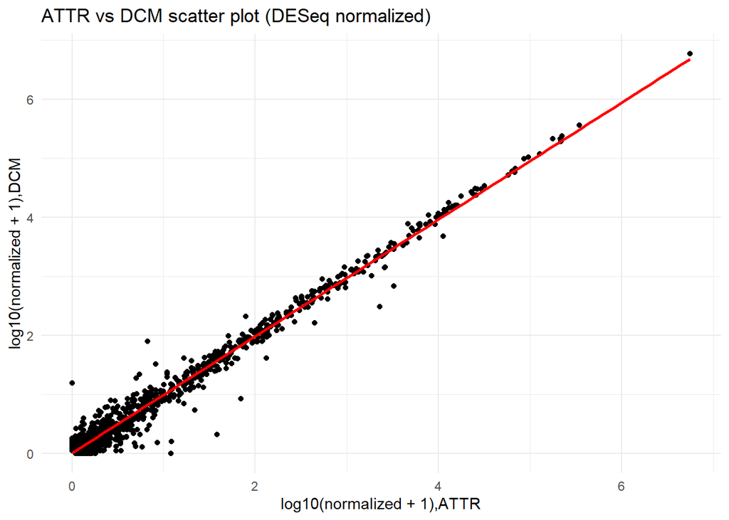

```r
ggplot(mean_data, aes(x = mean_ATTR, y = mean_DCM)) +
  geom_point() +
  geom_smooth(method = "lm", se = FALSE, color = "red") +
  labs(title="ATTR vs DCM scatter plot (DESeq normalized)",
       x = "log10(normalized + 1),ATTR",
       y = "log10(normalized + 1),DCM")+
  theme_minimal()
```

### Spearman correlation

Usando datos normalizados por DESeq.

```r
spe_data <- cor(normalized_counts, method="spearman")
spe_data <- melt(spe_data)
head(cor_data)
```

```
##    Var1  Var2     value
## 1 ATTR1 ATTR1 1.0000000
## 2 ATTR2 ATTR1 0.9701315
## 3 ATTR3 ATTR1 0.9659951
## 4 ATTR4 ATTR1 0.9628552
## 5 ATTR5 ATTR1 0.9482767
## 6 ATTR6 ATTR1 0.9640229
```

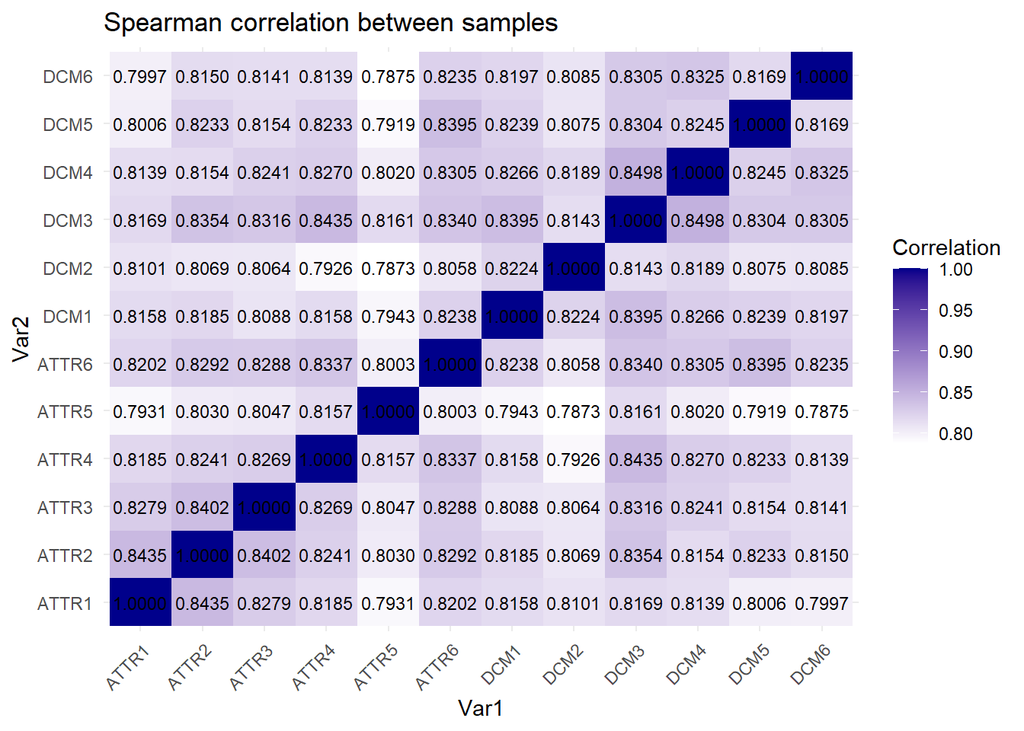

```r
sp<- ggplot(spe_data, aes(x=Var1, y=Var2, fill=value)) +
  geom_tile() +
  theme_minimal() +
   geom_text(aes(label = sprintf("%.4f", value)), color = "black", size = 3)+
  scale_fill_gradient(low = "white", high = "darkblue") +
  labs( fill = "Correlation") +
  theme(axis.text.x = element_text(angle = 45, hjust = 1))+
  ggtitle("Spearman correlation between samples")
print(sp)
```

```r
# jpeg("spearman.jpg", width = 800, height = 600)
# print(sp)
# dev.off()
```

### Kendall correlation

Usando datos normalizados por DESeq.

```r
ken_data <- cor(normalized_counts, method="kendall")
ken_data <- melt(ken_data)
head(ken_data)
```

```
##    Var1  Var2     value
## 1 ATTR1 ATTR1 1.0000000
## 2 ATTR2 ATTR1 0.7513944
## 3 ATTR3 ATTR1 0.7373574
## 4 ATTR4 ATTR1 0.7210572
## 5 ATTR5 ATTR1 0.6976372
## 6 ATTR6 ATTR1 0.7229369
```

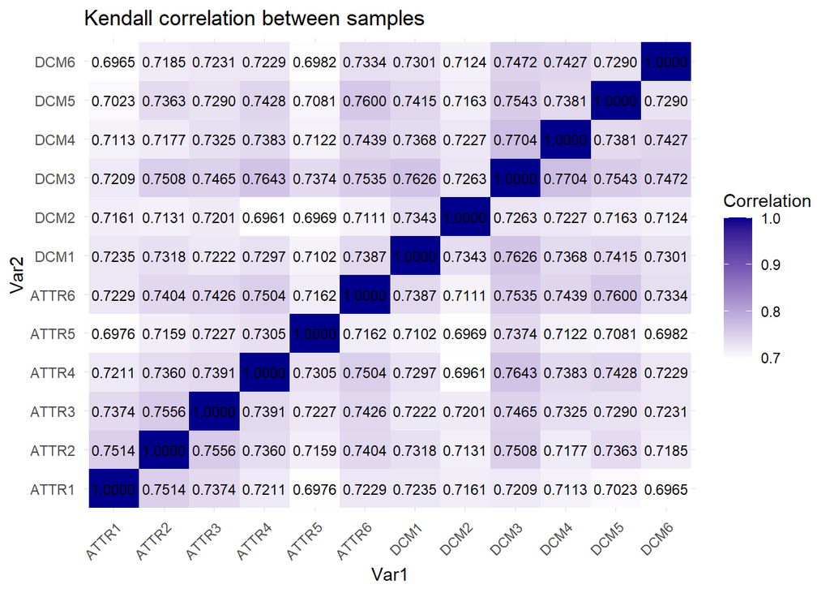

```r
k<-ggplot(ken_data, aes(x=Var1, y=Var2, fill=value)) +
  geom_tile() +
  theme_minimal() +
  geom_text(aes(label = sprintf("%.4f", value)), color = "black", size = 3)+
  scale_fill_gradient(low = "white", high = "darkblue") +
  labs( fill = "Correlation") +
  theme(axis.text.x = element_text(angle = 45, hjust = 1))+
  ggtitle("Kendall correlation between samples")
print(k)
```

```r
# jpeg("kendall.jpg", width = 800, height = 600)
# print(k)
# dev.off()
```

## Heatmap

```r
library(pheatmap)
```

Selecciona los miRNA significativos.

```r
orden <-order(significant_results$log2FoldChange, decreasing=TRUE)
sorted_significant_results <- significant_results[orden,]
selected_genes <- rownames(sorted_significant_results)
```

Datos ya normalizados por Novogene (contenidos en pre_counts_norm)

```r
TPM <- pre_counts_norm[selected_genes,]
#TPM[TPM == 0.00000] <- 0.0000001
print(TPM)
```

```
##                      ATTR1       ATTR2       ATTR3       ATTR4       ATTR5
## hsa-miR-4433a-5p   1.30046   0.6114416   1.0272327   1.4689691   4.0426841
## hsa-miR-4433b-3p   1.30046   0.6114416   1.0272327   1.4689691   4.0426841
## hsa-miR-124-3p     4.55161   4.4839051   3.8154356   4.2110446   7.3719533
## hsa-miR-1269b      1.20757   0.6114416   0.8804851   0.6855189   1.1890247
## hsa-miR-1298-5p    2.50803   0.5095347   1.7609703   2.2524192   1.6646346
## hsa-miR-96-5p      8.08143   7.3372992   6.1633960   8.4220893  17.8353710
## hsa-miR-196b-5p    1.11468   0.9171624   1.0272327   0.4896564   2.1402445
## hsa-miR-183-5p   259.81332 279.4288116 224.8172076 283.5110280 502.7196563
## hsa-miR-378i       1.02179   2.6495803   2.0544653   2.8400068   5.2317088
## hsa-miR-182-5p   360.22740 431.9834911 322.1108164 473.1059676 616.6282255
## hsa-miR-129-5p    15.51263  15.8974816  14.8215000  13.8083091  29.4878133
## hsa-miR-3529-3p  372.11732 307.7589391 322.8445540 307.1124642 386.9086475
## hsa-miR-7-5p     372.11732 307.7589391 322.8445540 307.1124642 386.9086475
## hsa-miR-140-3p   460.82727 554.8832529 585.8161180 670.3395463 463.2440352
## hsa-miR-200b-3p    4.27294   2.1400456   1.6142228   1.6648316   0.9512198
## hsa-miR-200c-3p    1.57913   0.4076277   1.0272327   1.0772440   0.4756099
## hsa-miR-217-5p     0.83601   0.8152555   0.7337376   0.6855189   0.0000000
## hsa-miR-375-3p     0.46445   0.6114416   0.5869901   0.6855189   1.1890247
## hsa-miR-205-5p     0.00000   0.0000000   0.0000000   0.0000000   0.0000000
##                        ATTR6        DCM1        DCM2        DCM3         DCM4
## hsa-miR-4433a-5p   1.3496438   0.0000000   0.0000000   0.0000000    0.0000000
## hsa-miR-4433b-3p   1.3496438   0.0000000   0.0000000   0.0000000    0.0000000
## hsa-miR-124-3p     4.1614017   0.1190563   0.1110559   0.2065788    0.3266500
## hsa-miR-1269b      0.0000000   0.0000000   0.1110559   0.1032894    0.0000000
## hsa-miR-1298-5p    0.7872922   0.0000000   0.0000000   0.3098682    0.0000000
## hsa-miR-96-5p      6.9731595   0.4762252   1.3326703   1.0328938    0.6533001
## hsa-miR-196b-5p    0.5623516   0.0000000   0.0000000   0.1032894    0.0000000
## hsa-miR-183-5p   225.8403923  27.0257785  68.4104065  34.9118120   36.5848042
## hsa-miR-378i       3.7115204   0.2381126   0.3331676   0.4131575    0.9799501
## hsa-miR-182-5p   297.1465719  57.6232459 174.5798035  86.1433469   74.2584418
## hsa-miR-129-5p    13.1590268   3.6907451  16.2141548   3.4085497    5.0086339
## hsa-miR-3529-3p  276.4520339 163.3452342 208.7850067 156.9998648  150.9123172
## hsa-miR-7-5p     276.4520339 163.3452342 208.7850067 156.9998648  150.9123172
## hsa-miR-140-3p   809.2239155 884.9454270 721.7519994 662.7046924 1389.6781419
## hsa-miR-200b-3p    2.3618766   4.4050828   5.9970162   4.4414435    5.4441673
## hsa-miR-200c-3p    1.4621141   2.7382947   4.7754018   4.0282860    5.0086339
## hsa-miR-217-5p     1.2371735   2.5001822   2.3321729   0.4131575    1.9599002
## hsa-miR-375-3p     0.8997625   7.6196028  10.7724179   8.4697295   10.8883346
## hsa-miR-205-5p     0.0000000   0.9524503   1.7768937   1.5493408    1.7421335
##                         DCM5         DCM6
## hsa-miR-4433a-5p   0.0000000    0.0000000
## hsa-miR-4433b-3p   0.0000000    0.0000000
## hsa-miR-124-3p     0.0000000    0.1184929
## hsa-miR-1269b      0.0000000    0.0000000
## hsa-miR-1298-5p    0.2716852    0.0000000
## hsa-miR-96-5p      0.6792131    1.3034222
## hsa-miR-196b-5p    0.0000000    0.5924647
## hsa-miR-183-5p    37.2208774   24.5280367
## hsa-miR-378i       0.5433705    0.9479434
## hsa-miR-182-5p    95.9048884   45.1458067
## hsa-miR-129-5p     2.9885376    3.3178021
## hsa-miR-3529-3p  162.1960861  163.9942166
## hsa-miR-7-5p     162.1960861  163.9942166
## hsa-miR-140-3p   920.8771086 1002.6871827
## hsa-miR-200b-3p    2.9885376    5.6876607
## hsa-miR-200c-3p    3.2602228    2.9623233
## hsa-miR-217-5p     2.0376393   18.9588690
## hsa-miR-375-3p     6.3846031   12.9157295
## hsa-miR-205-5p     1.6301114    3.3178021
```

Diferentes opciones de transformación de los datos para generar el heatmap:

```r
#OPCION 1
#heatmap_matrix <- as.matrix(log10(TPM+1))
#as.data.frame(heatmap_matrix)

#OPCION 2
# counts <-log10(TPM+1)
# heatmap_matrix<-as.matrix(log2(counts/rowMeans(counts)))
# as.data.frame(heatmap_matrix)

#OPCION 3
# raw <- normalized_counts[selected_genes,]
# heatmap_matrix <- as.matrix(log2(counts/ rowMeans(counts)))
# as.data.frame(heatmap_matrix)

#OPCION 4
# heatmap_matrix <- as.matrix(log2(log10(TPM+1)))
# as.data.frame(heatmap_matrix)

#OPCION 5
heatmap_matrix <- as.matrix(log2(normalized_counts[selected_genes,]/rowMeans(normalized_counts[selected_genes,])))
as.data.frame(heatmap_matrix)
```

```
##                       ATTR1      ATTR2      ATTR3       ATTR4      ATTR5
## hsa-miR-4433a-5p  0.5387814 -0.3731041  0.3710254  0.97128978  2.3451363
## hsa-miR-4433b-3p  0.5387814 -0.3731041  0.3710254  0.97128978  2.3451363
## hsa-miR-124-3p    0.7606040  0.9158327  0.6785779  0.90513162  1.6263374
## hsa-miR-1269b     1.4394653  0.6344951  1.1562321  0.87935326  1.5872007
## hsa-miR-1298-5p   1.4290625 -0.6933900  1.0913815  1.53070965  1.0077769
## hsa-miR-96-5p     0.5435810  0.5810695  0.3251990  0.85987504  1.8557033
## hsa-miR-196b-5p   0.8194111  0.7148806  0.8740475 -0.11065062  1.9306206
## hsa-miR-183-5p    0.4916297  0.7734850  0.4554098  0.87428554  1.6139718
## hsa-miR-378i     -0.9031400  0.6483751  0.2770273  0.82838211  1.6231070
## hsa-miR-182-5p    0.3518478  0.7907660  0.3630000  1.00182961  1.2974042
## hsa-miR-129-5p    0.2852898  0.4974947  0.3920409  0.37410955  1.3820288
## hsa-miR-3529-3p   0.4263901  0.3292833  0.3939753  0.40612602  0.6526890
## hsa-miR-7-5p      0.4263901  0.3292833  0.3939753  0.40612602  0.6526890
## hsa-miR-140-3p   -0.8692533 -0.4244452 -0.3505286 -0.07186101 -0.6916436
## hsa-miR-200b-3p   0.1204194 -0.7003181 -1.1114669 -0.98270696 -1.8768955
## hsa-miR-200c-3p  -0.7960913 -2.5730472 -1.2439552 -1.09114982 -2.3573072
## hsa-miR-217-5p   -1.7435639 -1.6029819 -1.7593168 -1.77316127       -Inf
## hsa-miR-375-3p   -3.6496746 -3.0761332 -3.1393586 -2.83127499 -2.1234275
## hsa-miR-205-5p         -Inf       -Inf       -Inf        -Inf       -Inf
##                        ATTR6       DCM1        DCM2       DCM3       DCM4
## hsa-miR-4433a-5p  0.52625659       -Inf        -Inf       -Inf       -Inf
## hsa-miR-4433b-3p  0.52625659       -Inf        -Inf       -Inf       -Inf
## hsa-miR-124-3p    0.56521513 -4.2393937 -4.34378584 -3.0460521 -3.1495906
## hsa-miR-1269b           -Inf       -Inf -1.75065436 -1.4529206       -Inf
## hsa-miR-1298-5p  -0.30860248       -Inf        -Inf -0.9328087       -Inf
## hsa-miR-96-5p     0.26470150 -3.2846502 -1.80407991 -1.7693805 -3.1948471
## hsa-miR-196b-5p  -0.23375571       -Inf        -Inf -1.9574976       -Inf
## hsa-miR-183-5p    0.22337636 -2.5167741 -1.18092826 -1.7491016 -2.4461646
## hsa-miR-378i      0.89169014 -2.7478594 -2.26728908 -1.5545178 -1.0730938
## hsa-miR-182-5p    0.00803313 -2.0356738 -0.44054373 -1.0572919 -2.0360685
## hsa-miR-129-5p   -0.01818218 -1.5295060  0.60173005 -1.2459666 -1.4552998
## hsa-miR-3529-3p  -0.06841972 -0.5047796 -0.15471958 -0.1636471 -0.9852922
## hsa-miR-7-5p     -0.06841972 -0.5047796 -0.15471958 -0.1636471 -0.9852922
## hsa-miR-140-3p   -0.12302196  0.3287725  0.03065350  0.3098437  0.6135641
## hsa-miR-200b-3p  -0.80095747  0.4210230  0.86206500  0.8311760  0.3602665
## hsa-miR-200c-3p  -0.97324682  0.2547200  1.05303061  1.2099019  0.7595606
## hsa-miR-217-5p   -1.24418967  0.0935407 -0.01085147 -2.1054351 -0.6240111
## hsa-miR-375-3p   -2.76173501  0.6431096  1.13863023  1.1940032  0.7918063
## hsa-miR-205-5p          -Inf  0.1424020  1.03800981  1.2426342  0.6472426
##                        DCM5        DCM6
## hsa-miR-4433a-5p       -Inf        -Inf
## hsa-miR-4433b-3p       -Inf        -Inf
## hsa-miR-124-3p         -Inf -4.53877277
## hsa-miR-1269b          -Inf        -Inf
## hsa-miR-1298-5p  -1.6137229        -Inf
## hsa-miR-96-5p    -2.8653322 -2.12459772
## hsa-miR-196b-5p        -Inf -0.12829024
## hsa-miR-183-5p   -2.1479006 -2.94921477
## hsa-miR-378i     -1.6504695 -1.04723851
## hsa-miR-182-5p   -1.3936228 -2.68026897
## hsa-miR-129-5p   -1.9268808 -1.97572651
## hsa-miR-3529-3p  -0.6078673 -0.79159523
## hsa-miR-7-5p     -0.6078673 -0.79159523
## hsa-miR-140-3p    0.2932903  0.21644751
## hsa-miR-200b-3p  -0.2316088  0.49715308
## hsa-miR-200c-3p   0.4135104  0.07563512
## hsa-miR-217-5p   -0.2944962  2.72377228
## hsa-miR-375-3p    0.2950883  1.11191479
## hsa-miR-205-5p    0.8247544  1.65037781
```

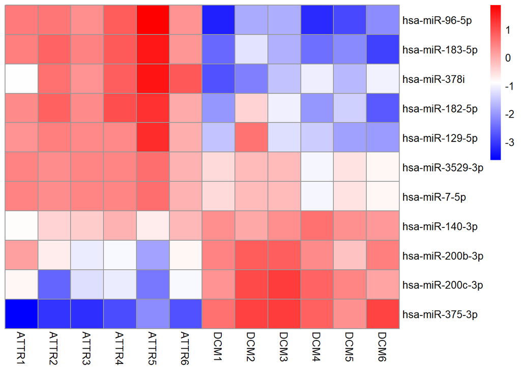

```r
heatmap_matrix <- heatmap_matrix[is.finite(rowSums(heatmap_matrix)),] #Eliminar valores infinitos

colores <- colorRampPalette(c("blue", "white", "red"))(256)# Especificar paleta de color
h<-pheatmap(heatmap_matrix, cluster_row= FALSE,cluster_cols = FALSE, col=colores)
```

```r
#jpeg("heatmap1.jpg", width = 800, height = 600)
#print(h)
#dev.off()
```

### OPCION EdgeR

```r
# #BiocManager::install("edgeR")
# library(edgeR)
#
# #TPM <- log10(TPM+1)
# y <- DGEList(counts=TPM)
# logcpm <- cpm(y, log=TRUE)
# pheatmap(y,cluster_cols = FALSE, legend_breaks = c(-2, 0, 2))
```

## PCA

Análisis de componentes principales (10), clusterizado por k-means y representación.

```r
clusterizado <- function (data) {

  #PCA + classification
pca_data <- t(data)
pca <- prcomp(pca_data) #Calculo los componentes principales de la tabla

pca_dataframe <- pca$x[,c(1:10)] # La x son los valores de las nuevas variables (o componentes principales) que ha calculado.

#Classificate using k-means
kmeans <- kmeans(pca_dataframe,2) #Agrupar muestras con k-means. Es de nuevo una lista con cluster, centers, x...
kmeans_dataframe <- data.frame (Cluster = as.factor(kmeans$cluster)) # Ahora creamos una dataframe filtrado por el agrupado de k-means, según el elemento cluster.

#Mix both dataframes
representation_dataframe <- cbind(pca_dataframe,kmeans_dataframe)
    # representation_dataframe$group <-breast_dataframe[,51]

#Represent PCA and k-means clusters
k<- ggplot(data=representation_dataframe, aes( x = PC2, y = PC1, colour = Cluster)) + geom_point()+ geom_label(aes(label = rownames(pca_data)), vjust = -1, hjust = 1)
print(k)

##Varianza explicada
prop_varianza <- pca$sdev^2 / sum(pca$sdev^2)

ggplot(data = data.frame(prop_varianza, pc = 1:4),
       aes(x = pc, y = prop_varianza)) +
  geom_col(width = 0.3) +
  scale_y_continuous(limits = c(0,1)) +
  theme_bw() +
  labs(x = "Componente principal",
       y = "Prop. de varianza explicada")
}
```

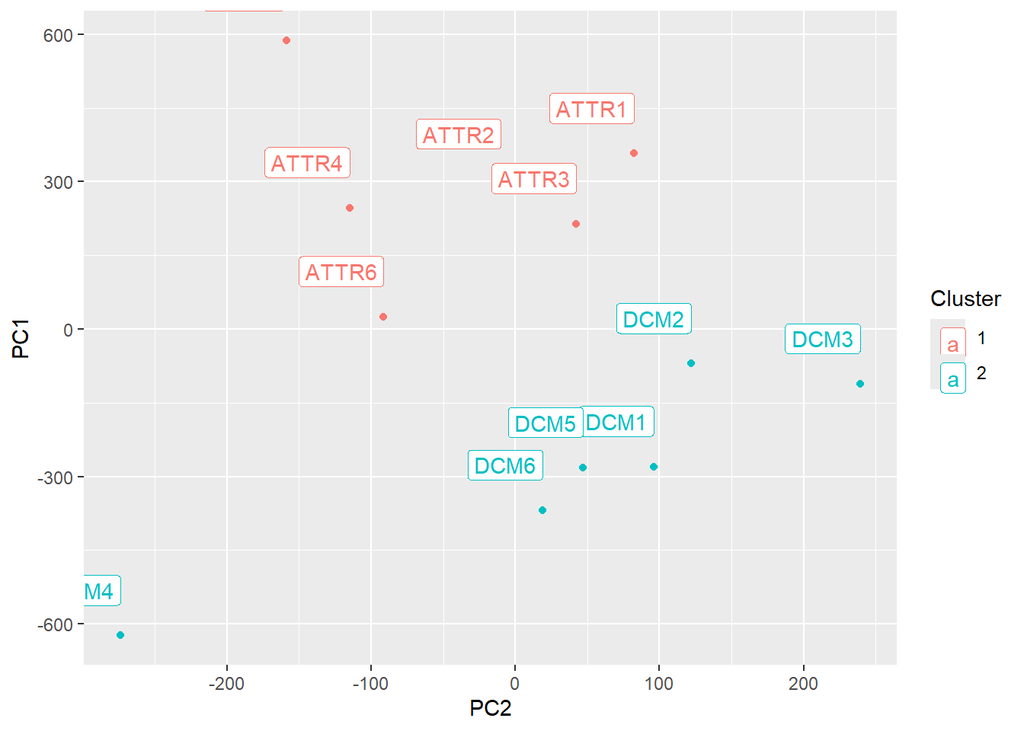

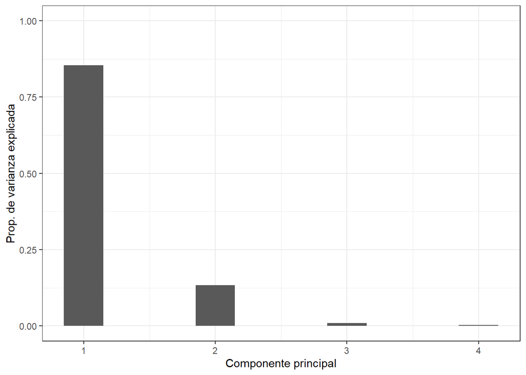

```r
clusterizado(TPM)
```

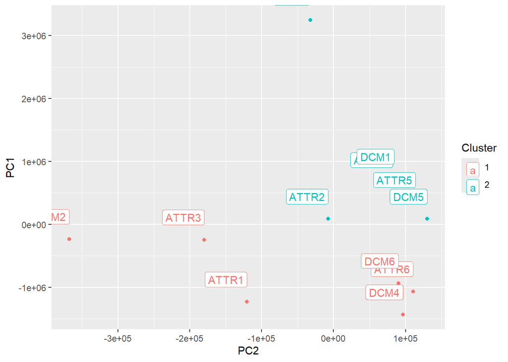

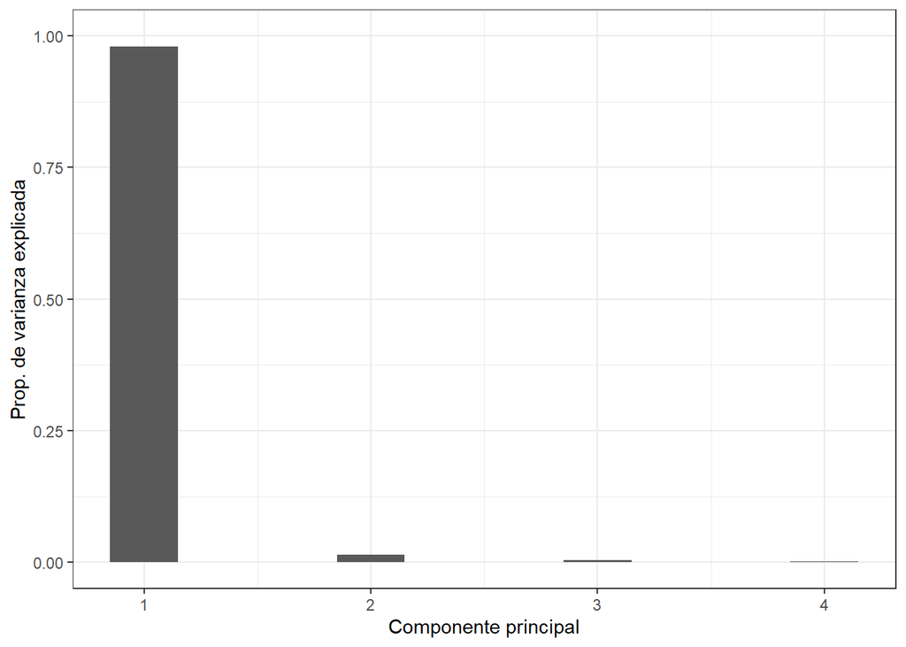

```r
clusterizado(normalized_counts)
```